# SALES ANALYSIS BASED ON CUSTOMER’S DEMOGRAPHICS AND COMPANY’S CAMPAIGNS

### SALES ANALYSIS BASED ON CUSTOMER’S DEMOGRAPHICS AND COMPANY’S CAMPAIGNS

### BUSINESS PROBLEM:

To identify the majority of the customer segments generating revenue, in which product portfolio does the sales increase, to understand which campaign has resulted in generating more revenue to the company and also to understand the company’s performance in various countries.

DATA SET LINK: https://www.kaggle.com/jackdaoud/marketing-data

### DATA DICTIONARY

ID:- ID of the customer

Year_Birth:- Date of birth of the customer

Education:- Education background of the customer

Marital_Status:- Marital status of the customer

INCOME:- Income of the customers

Kidhome:- Kids of the customers

Teen home:- Teens in the house of customers

Dt_Customer:- Date of purchase of the products

Recency:- Number of days since last purchase

MntWines:- Amount spend on wines products

MntFruits:- Amount spend on fruits products

MntMeatProducts:- Amount spend on meat products

MntFishProducts:- Amount spend on fish products

MntSweetProducts:- Amount spend on sweet products

MntGoldProds:- Amount spend on gold products

NumDealsPurchases:- Number of purchases made with discount

NumWebPurchases:- Number of purchases made from websites

NumCatalogPurchases:- Number of purchases made using catalogue

NumStorePurchases:- Number of purchases made from stores

NumWebVisitsMonth:- Number of visits to company’s website in the last months

AcceptedCmp1:- 1 if customers accepted

AcceptedCmp2:- 1 if customers accepted

AcceptedCmp3:- 1 if customers accepted

AcceptedCmp4:- 1 if customers accepted

AcceptedCmp5:- 1 if customers accepted

Response:- One if customers accepted in last campaign

Complain:- One of the customers complained

Country:- Countries of the sales

```python
import pandas as pd
import numpy as np
import seaborn as sns
import matplotlib.pyplot as plt
pd.pandas.set_option("display.max_columns",None)
```

```python
df= pd.read_csv("marketing_data.csv")
df.head()
```

|  | ID | Year_Birth | Education | Marital_Status | Income | Kidhome | Teenhome | Dt_Customer | Recency | MntWines | MntFruits | MntMeatProducts | MntFishProducts | MntSweetProducts | MntGoldProds | NumDealsPurchases | NumWebPurchases | NumCatalogPurchases | NumStorePurchases | NumWebVisitsMonth | AcceptedCmp3 | AcceptedCmp4 | AcceptedCmp5 | AcceptedCmp1 | AcceptedCmp2 | Response | Complain | Country |
| --- | --- | --- | --- | --- | --- | --- | --- | --- | --- | --- | --- | --- | --- | --- | --- | --- | --- | --- | --- | --- | --- | --- | --- | --- | --- | --- | --- | --- |
| 0 | 1826 | 1970 | Graduation | Divorced | $84,835.00 | 0 | 0 | 6/16/14 | 0 | 189 | 104 | 379 | 111 | 189 | 218 | 1 | 4 | 4 | 6 | 1 | 0 | 0 | 0 | 0 | 0 | 1 | 0 | SP |
| 1 | 1 | 1961 | Graduation | Single | $57,091.00 | 0 | 0 | 6/15/14 | 0 | 464 | 5 | 64 | 7 | 0 | 37 | 1 | 7 | 3 | 7 | 5 | 0 | 0 | 0 | 0 | 1 | 1 | 0 | CA |
| 2 | 10476 | 1958 | Graduation | Married | $67,267.00 | 0 | 1 | 5/13/14 | 0 | 134 | 11 | 59 | 15 | 2 | 30 | 1 | 3 | 2 | 5 | 2 | 0 | 0 | 0 | 0 | 0 | 0 | 0 | US |
| 3 | 1386 | 1967 | Graduation | Together | $32,474.00 | 1 | 1 | 5/11/14 | 0 | 10 | 0 | 1 | 0 | 0 | 0 | 1 | 1 | 0 | 2 | 7 | 0 | 0 | 0 | 0 | 0 | 0 | 0 | AUS |
| 4 | 5371 | 1989 | Graduation | Single | $21,474.00 | 1 | 0 | 4/8/14 | 0 | 6 | 16 | 24 | 11 | 0 | 34 | 2 | 3 | 1 | 2 | 7 | 1 | 0 | 0 | 0 | 0 | 1 | 0 | SP |

```python
df.describe()
```

|  | ID | Year_Birth | Kidhome | Teenhome | Recency | MntWines | MntFruits | MntMeatProducts | MntFishProducts | MntSweetProducts | MntGoldProds | NumDealsPurchases | NumWebPurchases | NumCatalogPurchases | NumStorePurchases | NumWebVisitsMonth | AcceptedCmp3 | AcceptedCmp4 | AcceptedCmp5 | AcceptedCmp1 | AcceptedCmp2 | Response | Complain |
| --- | --- | --- | --- | --- | --- | --- | --- | --- | --- | --- | --- | --- | --- | --- | --- | --- | --- | --- | --- | --- | --- | --- | --- |
| count | 2240.000000 | 2240.000000 | 2240.000000 | 2240.000000 | 2240.000000 | 2240.000000 | 2240.000000 | 2240.000000 | 2240.000000 | 2240.000000 | 2240.000000 | 2240.000000 | 2240.000000 | 2240.000000 | 2240.000000 | 2240.000000 | 2240.000000 | 2240.000000 | 2240.000000 | 2240.000000 | 2240.000000 | 2240.000000 | 2240.000000 |
| mean | 5592.159821 | 1968.805804 | 0.444196 | 0.506250 | 49.109375 | 303.935714 | 26.302232 | 166.950000 | 37.525446 | 27.062946 | 44.021875 | 2.325000 | 4.084821 | 2.662054 | 5.790179 | 5.316518 | 0.072768 | 0.074554 | 0.072768 | 0.064286 | 0.013393 | 0.149107 | 0.009375 |
| std | 3246.662198 | 11.984069 | 0.538398 | 0.544538 | 28.962453 | 336.597393 | 39.773434 | 225.715373 | 54.628979 | 41.280498 | 52.167439 | 1.932238 | 2.778714 | 2.923101 | 3.250958 | 2.426645 | 0.259813 | 0.262728 | 0.259813 | 0.245316 | 0.114976 | 0.356274 | 0.096391 |
| min | 0.000000 | 1893.000000 | 0.000000 | 0.000000 | 0.000000 | 0.000000 | 0.000000 | 0.000000 | 0.000000 | 0.000000 | 0.000000 | 0.000000 | 0.000000 | 0.000000 | 0.000000 | 0.000000 | 0.000000 | 0.000000 | 0.000000 | 0.000000 | 0.000000 | 0.000000 | 0.000000 |
| 25% | 2828.250000 | 1959.000000 | 0.000000 | 0.000000 | 24.000000 | 23.750000 | 1.000000 | 16.000000 | 3.000000 | 1.000000 | 9.000000 | 1.000000 | 2.000000 | 0.000000 | 3.000000 | 3.000000 | 0.000000 | 0.000000 | 0.000000 | 0.000000 | 0.000000 | 0.000000 | 0.000000 |
| 50% | 5458.500000 | 1970.000000 | 0.000000 | 0.000000 | 49.000000 | 173.500000 | 8.000000 | 67.000000 | 12.000000 | 8.000000 | 24.000000 | 2.000000 | 4.000000 | 2.000000 | 5.000000 | 6.000000 | 0.000000 | 0.000000 | 0.000000 | 0.000000 | 0.000000 | 0.000000 | 0.000000 |
| 75% | 8427.750000 | 1977.000000 | 1.000000 | 1.000000 | 74.000000 | 504.250000 | 33.000000 | 232.000000 | 50.000000 | 33.000000 | 56.000000 | 3.000000 | 6.000000 | 4.000000 | 8.000000 | 7.000000 | 0.000000 | 0.000000 | 0.000000 | 0.000000 | 0.000000 | 0.000000 | 0.000000 |
| max | 11191.000000 | 1996.000000 | 2.000000 | 2.000000 | 99.000000 | 1493.000000 | 199.000000 | 1725.000000 | 259.000000 | 263.000000 | 362.000000 | 15.000000 | 27.000000 | 28.000000 | 13.000000 | 20.000000 | 1.000000 | 1.000000 | 1.000000 | 1.000000 | 1.000000 | 1.000000 | 1.000000 |

```python
df.rename(columns={' Income ':'Income'},inplace=True)
df['Income'] = df['Income'].str.replace("$","").str.replace(",","")
df['Income'] = df['Income'].astype(float)
```

```python
df['Year_Birth']= df['Year_Birth'].replace({1899:1999})
df['Year_Birth']= df['Year_Birth'].replace({1900:1967})
df['Year_Birth']= df['Year_Birth'].replace({1893:1993})
```

There are three observation in the year_Birth column which are wrongly entered the data. So replaced those with an appropriate data

```python
df['Dt_Customer'] = pd.to_datetime(df['Dt_Customer'])
df['Purchase_year']= df['Dt_Customer'].dt.year
df['Age']= df['Purchase_year']-df['Year_Birth']
```

The Dt_Customer variable contains the date of customer purchases the products. So i have extracted the only year and from that I have derived a variable of the AGE of the customers by taking the difference between purchase_year and year_birth.

```python
Feature_nan= [features for features in df.columns if df[features].isnull().sum()>1]
for feature in Feature_nan:
    print(feature, np.round(df[feature].isnull().mean(),4),'% missing values')
for feature in Feature_nan:
    median_value= df[feature].median()
    df[feature+ 'nan']=np.where(df[feature].isnull(),1,0)
    df[feature].fillna(median_value,inplace=True)
df[Feature_nan].isnull().sum()
```

```
Income 0.0107 % missing values
```

```
Income    0
dtype: int64
```

```python
df['Expenditure']=df['MntWines']+df['MntFruits']+df['MntMeatProducts']+df['MntFishProducts']+df['MntSweetProducts']+df['MntGoldProds']
df.drop(['ID','Year_Birth','Dt_Customer'],axis='columns', inplace=True)
df['Campaigns']=df['AcceptedCmp1']+df['AcceptedCmp2']+df['AcceptedCmp3']+df['AcceptedCmp4']+df['AcceptedCmp5']+df['Response']
df['Sales']= df['NumDealsPurchases']+df['NumWebPurchases']+df['NumCatalogPurchases']+df['NumStorePurchases']
```

Derived a new variables Expenditure, Campaigns and Sales from various variables. Also droped unwanted variables from the dataset.

```python
df['Education']= df['Education'].replace({'2n Cycle':'Master'})
df['Marital_Status']= df['Marital_Status'].replace({'Alone':'Single'})
df['Dependents']= df['Kidhome']+df['Teenhome']
```

There are few categories which has same meaning so I have replaced the its respective categories. Also derived a new variable Dependents by combining the kidhome and teenhome variable

```python
df.drop(['Kidhome','Teenhome'],axis='columns', inplace=True)
df.drop(df[df['Marital_Status']=='Absurd'].index, inplace=True)
df.drop(df[df['Marital_Status']=='YOLO'].index, inplace=True)
```

Have dropped few catagories which are not having any meaning to them

```python
category = pd.cut(df.Age,bins=[0,15,21,55,120],labels=['Baby/Child','Teen age','Adult','Elderly'])
df.insert(5,'Age Group',category)
```

Created a Bins for the different age group

```python
df.drop(['Age'],axis='columns', inplace=True)
```

```python
df.to_excel('Modified2.xlsx', index=False)
```

Created a new file and named it as Modified2 which contains the cleaned data

```python
categorical_features=[feature for feature in df.columns if df[feature].dtypes=='O']
for feature in categorical_features:
    print('The feature is {} and number of categories are {}'.format(feature,len(df[feature].unique())))
    print('The feature is {} and number of categories are {}'.format(feature,(df[feature].unique())))
```

```
The feature is Education and number of categories are 4
The feature is Education and number of categories are ['Graduation' 'PhD' 'Master' 'Basic']
The feature is Marital_Status and number of categories are 5
The feature is Marital_Status and number of categories are ['Divorced' 'Single' 'Married' 'Together' 'Widow']
The feature is Country and number of categories are 8
The feature is Country and number of categories are ['SP' 'CA' 'US' 'AUS' 'GER' 'IND' 'SA' 'ME']
```

This explains the unique categories in each categorical variable

```python
Num_Feat= [feature for feature in df.columns if df[feature].dtypes != 'O']
print("Number of numerical variables: ",len(Num_Feat))
df[Num_Feat].head()
```

```
Number of numerical variables:  27
```

|  | Income | Recency | MntWines | Age Group | MntFruits | MntMeatProducts | MntFishProducts | MntSweetProducts | MntGoldProds | NumDealsPurchases | NumWebPurchases | NumCatalogPurchases | NumStorePurchases | NumWebVisitsMonth | AcceptedCmp3 | AcceptedCmp4 | AcceptedCmp5 | AcceptedCmp1 | AcceptedCmp2 | Response | Complain | Purchase_year | Incomenan | Expenditure | Campaigns | Sales | Dependents |
| --- | --- | --- | --- | --- | --- | --- | --- | --- | --- | --- | --- | --- | --- | --- | --- | --- | --- | --- | --- | --- | --- | --- | --- | --- | --- | --- | --- |
| 0 | 84835.0 | 0 | 189 | Adult | 104 | 379 | 111 | 189 | 218 | 1 | 4 | 4 | 6 | 1 | 0 | 0 | 0 | 0 | 0 | 1 | 0 | 2014 | 0 | 1190 | 1 | 15 | 0 |
| 1 | 57091.0 | 0 | 464 | Adult | 5 | 64 | 7 | 0 | 37 | 1 | 7 | 3 | 7 | 5 | 0 | 0 | 0 | 0 | 1 | 1 | 0 | 2014 | 0 | 577 | 2 | 18 | 0 |
| 2 | 67267.0 | 0 | 134 | Elderly | 11 | 59 | 15 | 2 | 30 | 1 | 3 | 2 | 5 | 2 | 0 | 0 | 0 | 0 | 0 | 0 | 0 | 2014 | 0 | 251 | 0 | 11 | 1 |
| 3 | 32474.0 | 0 | 10 | Adult | 0 | 1 | 0 | 0 | 0 | 1 | 1 | 0 | 2 | 7 | 0 | 0 | 0 | 0 | 0 | 0 | 0 | 2014 | 0 | 11 | 0 | 4 | 2 |
| 4 | 21474.0 | 0 | 6 | Adult | 16 | 24 | 11 | 0 | 34 | 2 | 3 | 1 | 2 | 7 | 1 | 0 | 0 | 0 | 0 | 1 | 0 | 2014 | 0 | 91 | 2 | 8 | 1 |

This gives the variables which are numeric

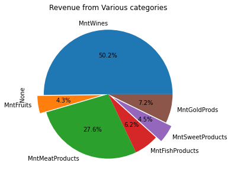

```python
df1= df[['MntWines','MntFruits','MntMeatProducts','MntFishProducts','MntSweetProducts','MntGoldProds']]
data = df1.sum()
plt.figure(figsize=(10,5))
plt.title('Revenue from Various categories')
data.plot.pie(autopct='%1.1f%%',explode=(0,0.1,0,0,0.1,0))
```

The majority of the revenue is generated from wine products, followed by meat products. Compared to all products the less revenue has been generated from the fruits and sweet products.

```python
New_Data=pd.get_dummies(df,drop_first=True)
```

This will convert all categorical into numerical data.

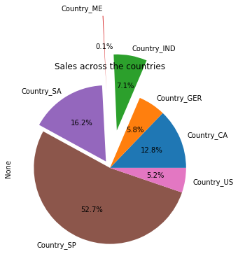

```python
df2= New_Data[['Country_CA','Country_GER','Country_IND','Country_ME','Country_SA','Country_SP','Country_US']]
data = df2.sum()
plt.figure(figsize=(10,5))
plt.title('Sales across the countries')
data.plot.pie(autopct='%1.1f%%',explode=(0,0,0.5,1,0.1,0,0))
```

This states that the maximum sales have been occurring in Spain, which is more than half of the sales, i.e., 52.7% and most minor sales, which are not even 1% sales in the overall sales, is happening in Mexico. 7.1% of sales are happening from India.

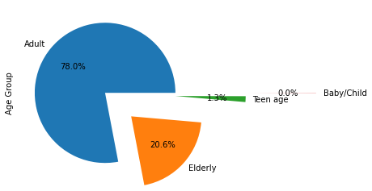

```python
df['Age Group'].value_counts().plot.pie(autopct='%1.1f%%',explode=(0,0.5,1,2))
```

This explains that the majority of the customers belongs to the adult with 78% and followed by the elders 20.6%.

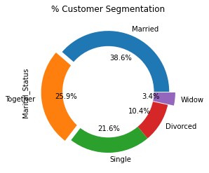

```python
df['Marital_Status'].value_counts().plot.pie(autopct='%1.1f%%',explode=(0,0.1,0,0,0.1))
circle= plt.Circle(xy=(0,0),radius=0.75,facecolor='white')
plt.gca().add_artist(circle)
plt.title('% Customer Segmentation')
```

This helps us to target the customers.The percentage of the people who are purchasing the goods. This helps to improve the company’s strategies to target the most earning categorical customers with their innovative advertisements and campaigns.

```python
df3=df[['MntWines','MntFruits','MntMeatProducts','MntFishProducts',
        'MntSweetProducts','MntGoldProds','Marital_Status']]
df3.head()
```

|  | MntWines | MntFruits | MntMeatProducts | MntFishProducts | MntSweetProducts | MntGoldProds | Marital_Status |
| --- | --- | --- | --- | --- | --- | --- | --- |
| 0 | 189 | 104 | 379 | 111 | 189 | 218 | Divorced |
| 1 | 464 | 5 | 64 | 7 | 0 | 37 | Single |
| 2 | 134 | 11 | 59 | 15 | 2 | 30 | Married |
| 3 | 10 | 0 | 1 | 0 | 0 | 0 | Together |
| 4 | 6 | 16 | 24 | 11 | 0 | 34 | Single |

Created a seperate data frame with only MntWines, MntFruits,MntMeatProducts, MntFishProducts, MntSweetProducts,MntGoldProds,Marital_Status for further analysis

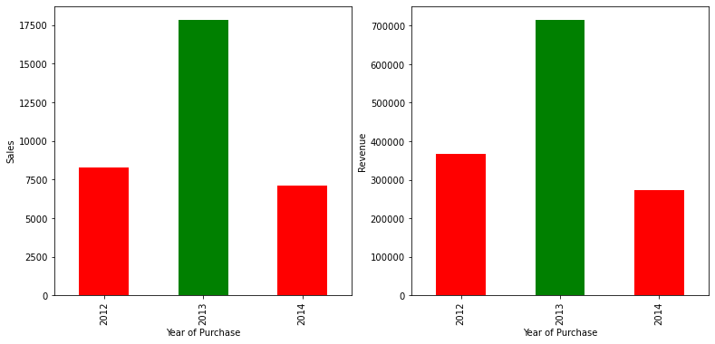

```python
plt.figure(figsize=(20,20))
plt.subplot(3,3,1)
data1=df.copy()
data1.groupby('Purchase_year')['Sales'].sum().plot.bar(color= ['red','green','red','yellow','orange'])
#circle= plt.Circle(xy=(0,0),radius=0.75,facecolor='white')
#plt.gca().add_artist(circle)
plt.xlabel('Year of Purchase')
plt.ylabel('Sales')

plt.subplot(3,3,2)
data1=df.copy()
data1.groupby('Purchase_year')['Expenditure'].sum().plot.bar(color= ['red','green','red','yellow','orange'])
#circle= plt.Circle(xy=(0,0),radius=0.75,facecolor='white')
#plt.gca().add_artist(circle)
plt.xlabel('Year of Purchase')
plt.ylabel('Revenue')
```

This tells us that the 2013 year has maximum number of sales and also generated maximum revenue compared to the other years.

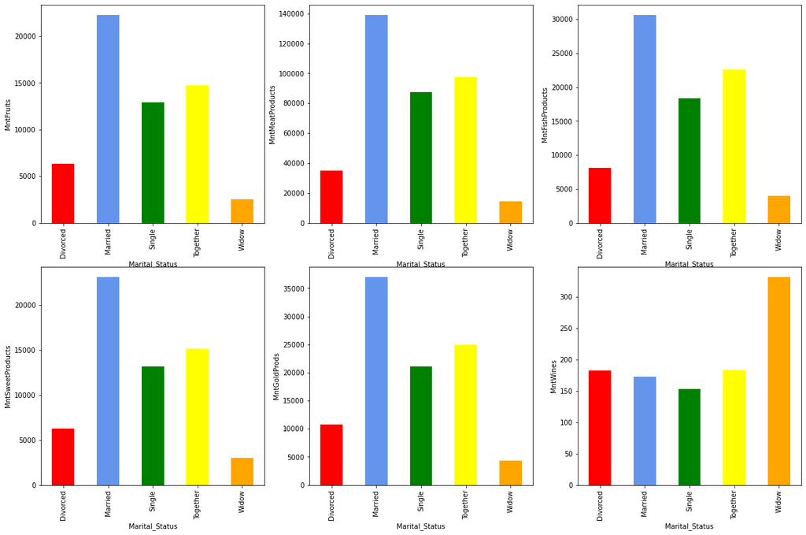

```python
plt.figure(figsize=(20,20))
plt.subplot(3,3,1)
data1=df3.copy()
data1.groupby('Marital_Status')['MntFruits'].sum().plot.bar(color= ['red','cornflowerblue','green','yellow','orange'])
plt.xlabel('Marital_Status')
plt.ylabel('MntFruits')

plt.subplot(3,3,2)
data1=df3.copy()
data1.groupby('Marital_Status')['MntMeatProducts'].sum().plot.bar(color= ['red','cornflowerblue','green','yellow','orange'])
plt.xlabel('Marital_Status')
plt.ylabel('MntMeatProducts')

plt.subplot(3,3,3)
data1=df3.copy()
data1.groupby('Marital_Status')['MntFishProducts'].sum().plot.bar(color= ['red','cornflowerblue','green','yellow','orange'])
plt.xlabel('Marital_Status')
plt.ylabel('MntFishProducts')

plt.subplot(3,3,4)
data1=df3.copy()
data1.groupby('Marital_Status')['MntSweetProducts'].sum().plot.bar(color= ['red','cornflowerblue','green','yellow','orange'])
plt.xlabel('Marital_Status')
plt.ylabel('MntSweetProducts')

plt.subplot(3,3,5)
data1=df3.copy()
data1.groupby('Marital_Status')['MntGoldProds'].sum().plot.bar(color= ['red','cornflowerblue','green','yellow','orange'])
plt.xlabel('Marital_Status')
plt.ylabel('MntGoldProds')

plt.subplot(3,3,6)
data1=df3.copy()
data1.groupby('Marital_Status')['MntWines'].median().plot.bar(color= ['red','cornflowerblue','green','yellow','orange'])
plt.xlabel('Marital_Status')
plt.ylabel('MntWines')
```

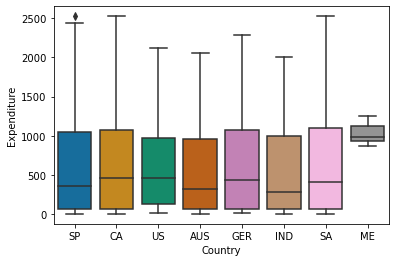

```python
sns.boxplot(y='Expenditure', x='Country',
                 data=df,
                 palette="colorblind")
```

The countries expenditure capacity of the customers varies based on their income and dependents. So here, Canada, Saudi Arabia and Spain have almost the same expenditure capacity with one outlier in Spain, which brings the revenue more than other countries.

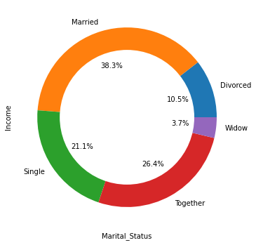

```python
plt.figure(figsize=(20,20))
plt.subplot(3,2,1)
df.groupby('Marital_Status')['Income'].sum().plot.pie(autopct='%1.1f%%',explode=(0,0,0,0,0))
circle= plt.Circle(xy=(0,0),radius=0.75,facecolor='white')
plt.gca().add_artist(circle)
plt.xlabel('Marital_Status')
plt.ylabel('Income')
```

This helps us to target the customers. Married people have more earning capacity. This helps to improve the company’s strategies to target the most earning categorical customers with their innovative advertisements and campaigns.

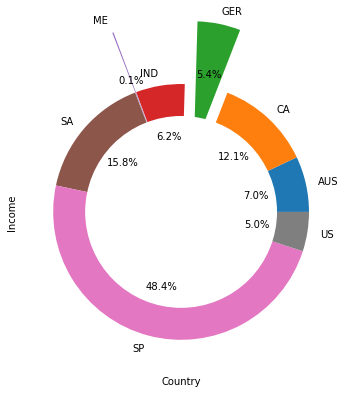

```python
plt.figure(figsize=(20,20))
plt.subplot(3,2,2)
df.groupby('Country')['Income'].sum().plot.pie(autopct='%1.1f%%',explode=(0,0,0.5,0,0.5,0,0,0))
circle= plt.Circle(xy=(0,0),radius=0.75,facecolor='white')
plt.gca().add_artist(circle)
plt.xlabel('Country')
plt.ylabel('Income')
```

This helps us to target the customers and the locality. We can understand that most of the earning capacity has been occurring in the Spain country.

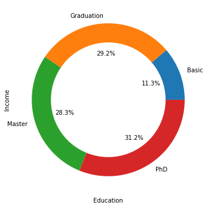

```python
plt.figure(figsize=(20,20))
plt.subplot(3,2,3)
df.groupby('Education')['Income'].mean().plot.pie(autopct='%1.1f%%',explode=(0,0,0,0))
circle= plt.Circle(xy=(0,0),radius=0.75,facecolor='white')
plt.gca().add_artist(circle)
plt.xlabel('Education')
plt.ylabel('Income')
```

The customers who did a PhD has more average income than other educational backgrounds have more earning capacity. This helps to improve the company’s strategies to target the most earning categorical customers with their innovative advertisements and campaigns.

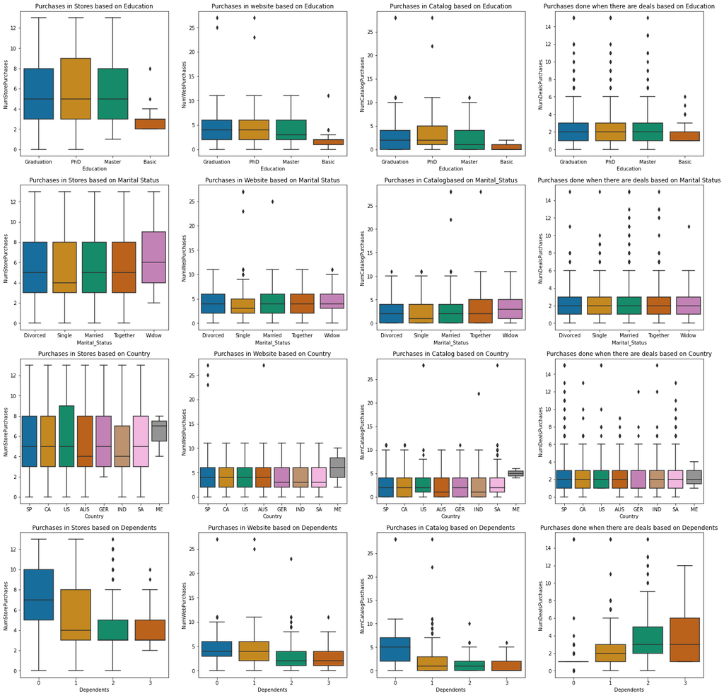

```python
plt.figure(figsize=(25,25))
plt.subplot(4,4,1)
plt.title('Purchases in Stores based on Education')
sns.boxplot(y='NumStorePurchases', x='Education',
                 data=df,
                 palette="colorblind")
plt.subplot(4,4,2)
plt.title('Purchases in website based on Education')
sns.boxplot(y='NumWebPurchases', x='Education',
                 data=df,
                 palette="colorblind")
plt.subplot(4,4,3)
plt.title('Purchases in Catalog based on Education')
sns.boxplot(y='NumCatalogPurchases', x='Education',
                 data=df,
                 palette="colorblind")
plt.subplot(4,4,4)
plt.title('Purchases done when there are deals based on Education')
sns.boxplot(y='NumDealsPurchases', x='Education',
                 data=df,
                 palette="colorblind")
plt.subplot(4,4,5)
plt.title('Purchases in Stores based on Marital Status')
sns.boxplot(y='NumStorePurchases', x='Marital_Status',
                 data=df,
                 palette="colorblind")
plt.subplot(4,4,6)
plt.title('Purchases in Website based on Marital Status')
sns.boxplot(y='NumWebPurchases', x='Marital_Status',
                 data=df,
                 palette="colorblind")
plt.subplot(4,4,7)
plt.title('Purchases in Catalogbased on Marital_Status')
sns.boxplot(y='NumCatalogPurchases', x='Marital_Status',
                 data=df,
                 palette="colorblind")
plt.subplot(4,4,8)
plt.title('Purchases done when there are deals based on Marital Status')
sns.boxplot(y='NumDealsPurchases', x='Marital_Status',
                 data=df,
                 palette="colorblind")
plt.subplot(4,4,9)
plt.title('Purchases in Stores based on Country')
sns.boxplot(y='NumStorePurchases', x='Country',
                 data=df,
                 palette="colorblind")
plt.subplot(4,4,10)
plt.title('Purchases in Website based on Country')
sns.boxplot(y='NumWebPurchases', x='Country',
                 data=df,
                 palette="colorblind")
plt.subplot(4,4,11)
plt.title('Purchases in Catalog based on Country')
sns.boxplot(y='NumCatalogPurchases', x='Country',
                 data=df,
                 palette="colorblind")
plt.subplot(4,4,12)
plt.title('Purchases done when there are deals based on Country')
sns.boxplot(y='NumDealsPurchases', x='Country',
                 data=df,
                 palette="colorblind")
plt.subplot(4,4,13)
plt.title('Purchases in Stores based on Dependents')
sns.boxplot(y='NumStorePurchases', x='Dependents',
                 data=df,
                 palette="colorblind")
plt.subplot(4,4,14)
plt.title('Purchases in Website based on Dependents')
sns.boxplot(y='NumWebPurchases', x='Dependents',
                 data=df,
                 palette="colorblind")
plt.subplot(4,4,15)
plt.title('Purchases in Catalog based on Dependents')
sns.boxplot(y='NumCatalogPurchases', x='Dependents',
                 data=df,
                 palette="colorblind")
plt.subplot(4,4,16)
plt.title('Purchases done when there are deals based on Dependents')
sns.boxplot(y='NumDealsPurchases', x='Dependents',
                 data=df,
                 palette="colorblind")
```

Column one: Purchases done from stores

Column two: Purchases done from the website

Column three: Purchases done from the catalogue

Column four: Purchases are made where there are deals on various products

Row one: Education background of the customers

Row two: Marital status of the customers 29

Row three: Various countries

Row four: Number of dependents

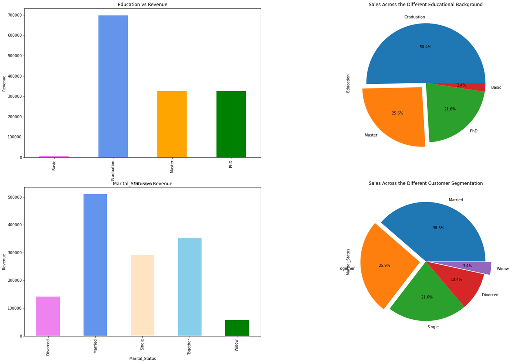

```python
plt.figure(figsize=(25,25))
plt.subplot(3,2,1)
data=df.copy()
data.groupby('Education')['Expenditure'].sum().plot.bar(color=['violet','cornflowerblue','orange','green'])
plt.xlabel('Education')
plt.ylabel('Revenue')
plt.title('Education vs Revenue')
plt.subplot(3,2,2)
data['Education'].value_counts().plot.pie(autopct='%1.1f%%', explode=(0,0.1,0,0))
plt.title('Sales Across the Different Educational Background')
plt.subplot(3,2,3)
data.groupby('Marital_Status')['Expenditure'].sum().plot.bar(color=['violet','cornflowerblue','bisque','skyblue','green','orange','violet'])
plt.xlabel('Marital_Status')
plt.ylabel('Revenue')
plt.title('Marital_Status vs Revenue')
plt.subplot(3,2,4)
df['Marital_Status'].value_counts().plot.pie(autopct='%1.1f%%', explode=(0,0.1,0,0,0.1))
plt.title('Sales Across the Different Customer Segmentation')
```

The above representation will conclude that most sales and revenue are generated from the married and graduated customers compared to other groups of customers. So, the company has to target married and graduated background customers to maintain customer retention. Also, should attract the other group of people by coming with innovative marketing to get customer acquisition.

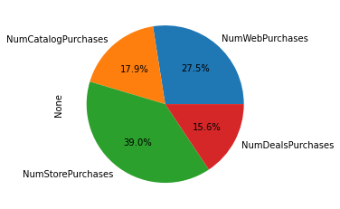

```python
df6= df[['NumWebPurchases', 'NumCatalogPurchases',  'NumStorePurchases','NumDealsPurchases']]
data = df6.sum()
data.plot.pie(autopct='%1.1f%%', explode=(0,0,0,0))
```

The majority of the sales are happening from the physical stores compared to online purchases. This helps to maintain the stocks in the stores to maintain customer retention.

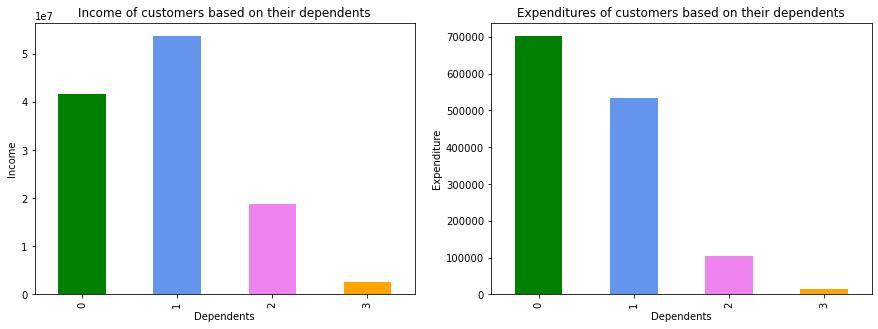

```python
plt.figure(figsize=(15,5))
plt.subplot(1,2,1)
df.groupby('Dependents')['Income'].sum().plot.bar(color=['green','cornflowerblue','violet','orange'])
plt.xlabel('Dependents')
plt.ylabel('Income')
plt.title('Income of customers based on their dependents')

plt.subplot(1,2,2)
df.groupby('Dependents')['Expenditure'].sum().plot.bar(color=['green','cornflowerblue','violet','orange'])
plt.xlabel('Dependents')
plt.ylabel('Expenditure')
plt.title('Expenditures of customers based on their dependents')
```

There is more impact of dependents on the sales of the various products. Suppose we observe the income and expenditure of the customers. In that case, the income is more for the customer who has one dependent, whereas the expenditure spent on the products is less than the customers who have zero dependents. By this, it is clear that irrespective of the income, as the number of dependents increases, the expenditure spent on the products will decrease. This is because of the decrease in the frequency of purchasing the products by the customers.

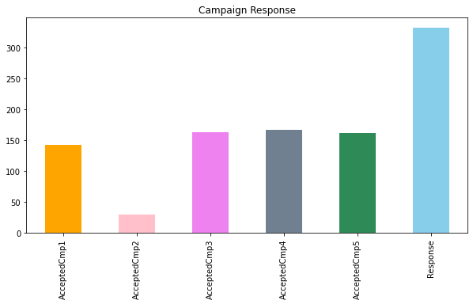

```python
df7= df[['AcceptedCmp1','AcceptedCmp2','AcceptedCmp3','AcceptedCmp4','AcceptedCmp5','Response']]
data = df7.sum()
plt.figure(figsize=(10,5))
plt.title('Campaign Response')
data.plot.bar(color=['orange','pink','violet','slategrey','seagreen','skyblue'])
```

The above graph represents the impact created in the customer to purchase the various products due to the campaigns conducted by the company. This states that the recent campaign conducted by the company impacted more customers to purchase more products on various platforms. There is a drop-down in sales during the second campaign but maintained in their third, fourth and fifth campaign.

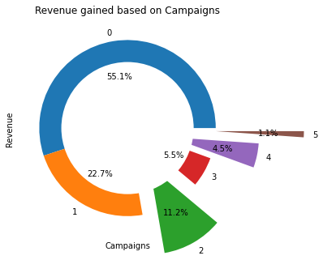

```python
plt.figure(figsize=(15,5))
plt.subplot(1,2,1)
df.groupby('Campaigns')['Expenditure'].sum().plot.pie(autopct='%1.1f%%',explode=(0,0,0.5,0,0.5,1))
circle= plt.Circle(xy=(0,0),radius=0.75,facecolor='white')
plt.gca().add_artist(circle)
plt.xlabel('Campaigns')
plt.ylabel('Revenue')
plt.title('Revenue gained based on Campaigns')
```

By this, we can understand that customers don’t have an impact on purchasing the products due to the campaigns conducted by the company. This tells that the company has a good customer base.

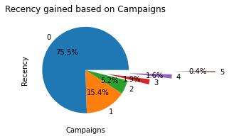

```python
plt.subplot(1,2,2)
df.groupby('Campaigns')['Recency'].sum().plot.pie(autopct='%1.1f%%', explode=(0,0,0,0.5,1,2))
plt.xlabel('Campaigns')
plt.ylabel('Recency')
plt.title('Recency gained based on Campaigns')
```

This tells us that majority of the customers are not attracted by any of the campaigns.

Recommendations:

1. Customers visit the stores to purchase the products to meet the demand; the company has to maintain sufficient inventory inventories.
2. The company has to develop more innovative campaigns and reach out to the customers because many customers don’t have impacted campaigns in their purchases.
3. The company has to conduct its campaigns more in the countries like Mexico, where therc e are fewer sales.
4. The company has to target educated customers primarily followed by the other to improve their sales and revenue.
5. Though there are more sales from married customers, the company has to attract other customers to improve its customer base.

Conclusions:

The project will help the company to know their effective customers. The report will help them to improve their innovative campaigns to reach out to the customers. This helps them spread their wings and their customer base in different geographical areas with a clear strategy to improve their sales and revenue.